# Mapping QBC Oyster Leases

Katie Lankowicz

## Mapping Basics

Mapping in R has a fairly steep learning curve, but it pays off. You can write code to create detailed, personalized maps and save the code so you can quickly and easily repeat the process. This is an improvement over ArcMap, QGIS, and other “point-and-click” methods of creating maps, which are not as good for creating consistent workflows and exact replications of your original work. We will be relying heavily on two packages: `ggplot2` for plotting functions and `sf` for handling spatial data. You may need to install the `sf` package– please do this in the console by typing `install.packages('sf')`. Remember that you only need to install packages once, though you will need to load the package every time you open R.

Spatial data has three main characteristics: extent, resolution, and accuracy. Extent refers to the spatial area covered by the data. Large spatial extent could be something like the entire North American continent, while small spatial extent could be something like just Casco Bay. Resolution is the “detail” of the data, or the smallest difference between adjacent positions that can be recorded. For paper maps, resolution is closely tied to extent– there is a physical limit to how small and thin of a line the human hand can draw, and therefore paper maps that require high resolution will need to be drawn on large pieces of paper so we can actually draw super-fine details. For digital maps, spatial information can be stored down to a resolution of a few centimeters. The practical limit of spatial resolution for digital maps is still slightly tied to extent– digital maps that require both high spatial resolution and large spatial extent will take up a lot of storage space on your laptop, and will be difficult to load and share. The final characteristic of maps is accuracy– how closely does your map represent the real world? How current are your data? This is a particular concern for coastline data, as ocean currents and fine sands can cause coastlines to shift over time.

Both digital and paper maps have to have a method for gridding and representing spatial data. These are called coordinate reference systems (CRS). A CRS defines the way that two-dimensional maps represent locations in the real world. CRS can either be geographic (latitude and longitude only) or projected (slightly altered in a way that better preserves objects’ shapes or positions relative to each other, given that the earth is curved and not actually flat).

## Your data

I have downloaded and shared with you (in this folder) a detailed shapefile of the Maine coastline. Shapefiles are the file type used for storing and sharing spatial information, much in the same way that .doc files are used to store and share Microsoft Word files. The shapefile has high resolution, high accuracy, and small spatial extent so that we can best view the little islands and coves that make up Casco Bay.

Finally, we will create a dataframe that contains the site names and latitude-longitude locations for our two oyster leases. We will then map and combine all these pieces of data to create a map for your paper.

When we plot all these things together, we need to make sure they all have the same coordinate reference system. If we don’t check the CRS, we could be plotting things that are built on different grids and therefore will not line up with each other to accurately represent our spatial area.

Let’s load the data I shared with you and see what it looks like.

```r
# Load the shapefile I sent to you
# This function, st_read(), is the shapefile equivalent of read.csv(), which we have used to load csv data. I include the argument "quiet=TRUE" to prevent the function from printing a bunch of shit
qbc <- st_read(here("us_medium_shoreline_poly.shp"), quiet=TRUE)

# Check the CRS
st_crs(qbc)
```

```
Coordinate Reference System:
  User input: NAD83
  wkt:
GEOGCRS["NAD83",
    DATUM["North American Datum 1983",
        ELLIPSOID["GRS 1980",6378137,298.257222101,
            LENGTHUNIT["metre",1]]],
    PRIMEM["Greenwich",0,
        ANGLEUNIT["degree",0.0174532925199433]],
    CS[ellipsoidal,2],
        AXIS["latitude",north,
            ORDER[1],
            ANGLEUNIT["degree",0.0174532925199433]],
        AXIS["longitude",east,
            ORDER[2],
            ANGLEUNIT["degree",0.0174532925199433]],
    ID["EPSG",4269]]
```

This is an unprojected (geographic) coordinate reference system based on the North American 1983 Datum (geographic data collection that finished in 1983, focusing on the North American continent). We can change this later if we want, but for now it’s fine. Let’s plot it.

Before, we were using geom_histogram and geom_boxplot to create histograms and boxplots. Now, we will use geom_sf to represent spatial data loaded with the sf package.

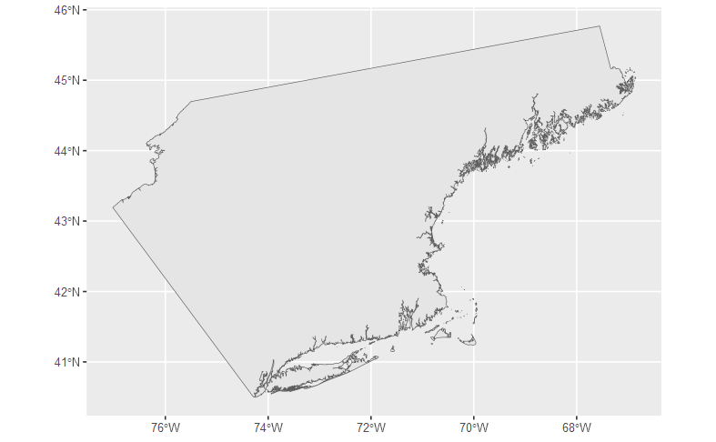

```r
# Plot using ggplot
ggplot() +
  geom_sf(data=qbc)
```

This is the entire extent of the fine-resolution shapefile. It is a polygon of most of the landmass of Maine through New York. Notice that it looks kinda weird. The original dataset was taken from NOAA and was composed of lines that represented the coasts. I had to connect these lines and essentially “fill in” the area that represents New York through Maine to create a polygon, and I didn’t care too much about representing areas of Northern Maine and Western New York that are far from the coasts.I also got frustrated trying to outline Cape Cod and decided it didn’t matter when we are trying to represent the Maine coast anyway, so I stopped trying to fix it.

This leads us into another concept: what kind of spatial data can shapefiles represent? You can have polygons like this, which are “filled in” representations of an object with calculable area. You can also have lines, which are representations of objects of a given length that extend in space without area. Finally, you can have points, which are objects without area or length. This sounds complicated but think of it this way: polygons(squares, circles, triangles, etc.), lines(just a line), points(just a dot).

Our shapefile has too much space represented. We don’t care about the coastline outside of midcoast Maine for this project. We can “zoom in” to an area of our extent that is a better representation of our study area, and so exclude the rest of our shapefile without deleting anything. Let’s do that.

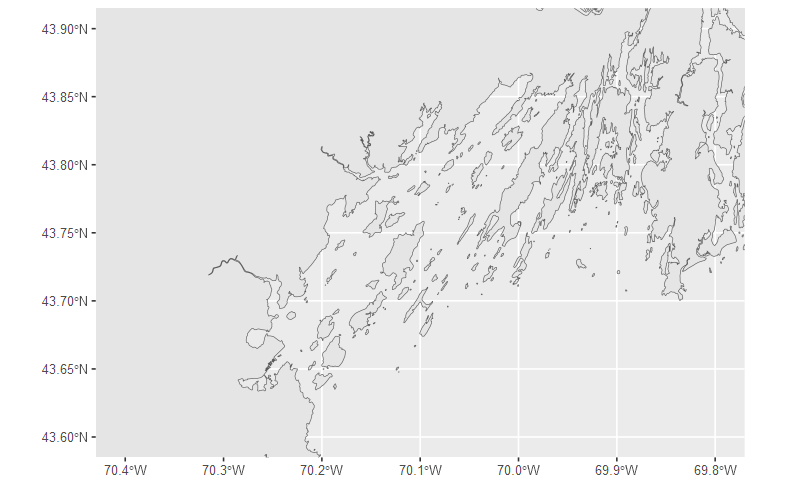

```r
# Plot with zoomed-in extent on Casco Bay.
ggplot() +
  geom_sf(data=qbc) +
  coord_sf(xlim=c(-70.4, -69.8),
           ylim=c(43.6, 43.9))
```

```r
# The coord_sf() function tells ggplot that we want it to zoom in on a window with the given x-axis limits and y-axis limits.

# These limits are equal to the latitude and longitude that create a box around Casco Bay.

# I already knew what these would be. You can play around with the values to zoom in and out as you wish.
```

This is a good representation for Casco Bay - Cape Elizabeth through Phippsburg. We can get even finer to focus on the area around QBC.

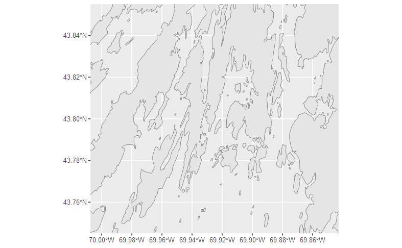

```r
# Plot with zoomed-in extent on QBC
ggplot() +
  geom_sf(data=qbc) +
  coord_sf(xlim=c(-70.00, -69.85),
           ylim=c(43.75, 43.85))
```

Wow, that’s a far zoom! We can see Quahog Bay in the center of the map and Dog’s Head to the center-left. But even though we can easily pick out our oyster leases, zooming in this far makes it really hard to interpret where you are along the Maine coast. For this reason, we will be making a second map, which will have a little box around where Quahog Bay can be found along the Maine coast.

Let’s load the low-resolution shapefile to pull up a map of Maine. I have also provided this shapefile in the folder.

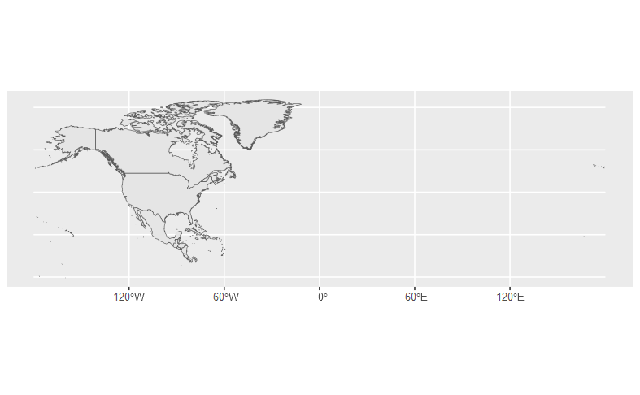

```r
# Load low-resolution coastline shapefile
coast <- st_read(here('us_coarse_coastline_poly.shp'))
# Plot
ggplot() +
  geom_sf(data=coast)
```

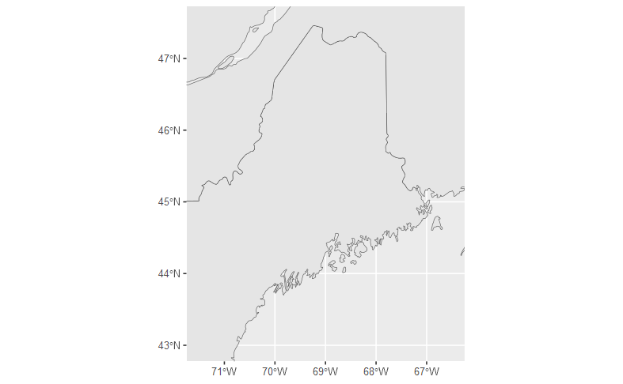

```r
# Look, it's all of North America and Greenland. We don't really want that.

# Plot with proper zoom
ggplot() +
  geom_sf(data=coast) +
  coord_sf(xlim=c(-71.5, -66.5),
           ylim=c(43, 47.5))
```

Cool. Now we can use this as a second map to help give us spatial context.

```r
# Make and save map of Quahog Bay
qbc_map <- ggplot() +
  geom_sf(data=qbc) +
  coord_sf(xlim=c(-70.00, -69.85),
           ylim=c(43.75, 43.85))

# Make and save map of Maine
maine_map <- ggplot() +
  geom_sf(data=coast) +
  coord_sf(xlim=c(-71, -66.8),
           ylim=c(43.2, 47.4))

# Combine into a single image with two panels
library(patchwork)
combined_map <- maine_map + qbc_map
```

|  | t | l | b | r |
| --- | --- | --- | --- | --- |
| 1: | 1 | 1 | 1 | 1 |
| 2: | 1 | 2 | 1 | 2 |

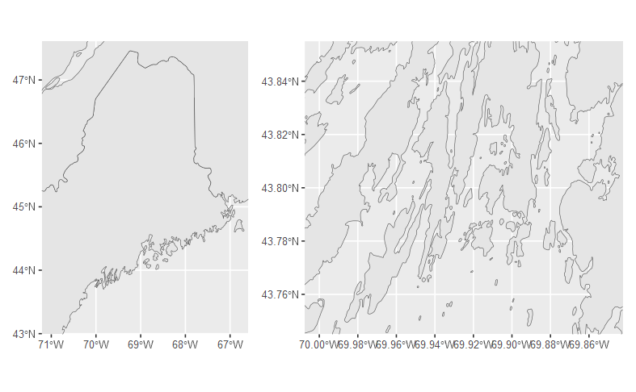

```r
# Show the map we just made
combined_map
```

So that’s pretty cool! Now we can add a little red box in the Maine map that surrounds the area showing the map of Quahog Bay, which will make it really obvious where we are focused.

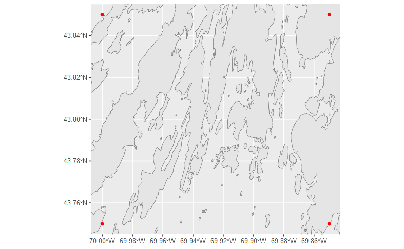

```r
# Create a dataframe that has the coordinates of QBC map extent
# These will be four points-- one on each corner of our QBC map extent.
qbc.extent <- data.frame(
  lat = c(43.75, 43.75, 43.85, 43.85),
  lon = c(-70.00, -69.85, -69.85, -70.00)
)

# Convert dataframe to spatial object
qbc.extent <- st_as_sf(qbc.extent, coords=c('lon', 'lat'))

# Set coordinate reference system to be the same as our other maps
st_crs(qbc.extent) <- st_crs(qbc)

# Plot in QBC map to make sure it makes sense
# Should show four points, one at each corner of the map
ggplot() +
  geom_sf(data=qbc) +
  geom_sf(data=qbc.extent, col='red') +
  coord_sf(xlim=c(-70.00, -69.85),
           ylim=c(43.75, 43.85))
```

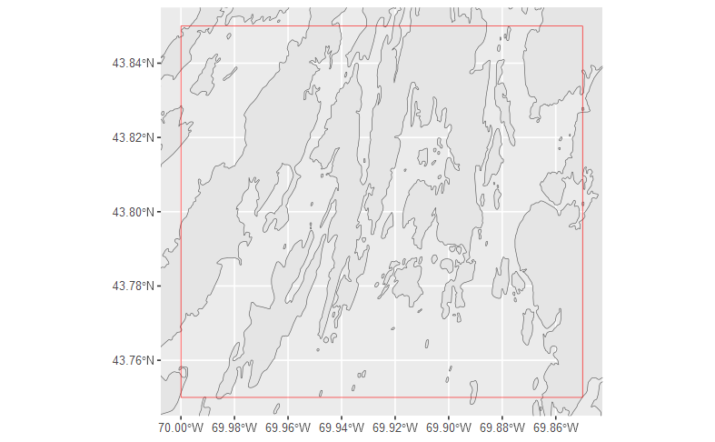

```r
# Convert qbc.extent from points to polygon (square)
# First, add column denoting group (so R knows all 4 points are part of the same object)
# Then, summarize the geometry so R knows this object is a square
# Finally, "cast" (convert) the points to become a polygon.
qbc.extent$group <- 1
qbc.extent <- qbc.extent %>%
  group_by(group) %>%
  summarise(geometry = st_combine(geometry)) %>%
  st_cast("POLYGON")

# Plot to make sure it makes sense
# Should now show a red-outlined square with no color fill over Quahog Bay.
ggplot() +
  geom_sf(data=qbc) +
  geom_sf(data=qbc.extent, col='red', fill=NA) +
  coord_sf(xlim=c(-70.00, -69.85),
           ylim=c(43.75, 43.85))
```

```r
# Put this square encapsulating Quahog Bay on the map of Maine
maine_map <- ggplot() +
  geom_sf(data=coast) +
  geom_sf(data=qbc.extent, col='red', fill=NA, lwd=1) +
  coord_sf(xlim=c(-71, -66.8),
           ylim=c(43.2, 47.4))

# Re-plot combined Maine and QBC maps
combined_map <- maine_map + qbc_map
```

|  | t | l | b | r |
| --- | --- | --- | --- | --- |
| 1: | 1 | 1 | 1 | 1 |
| 2: | 1 | 2 | 1 | 2 |

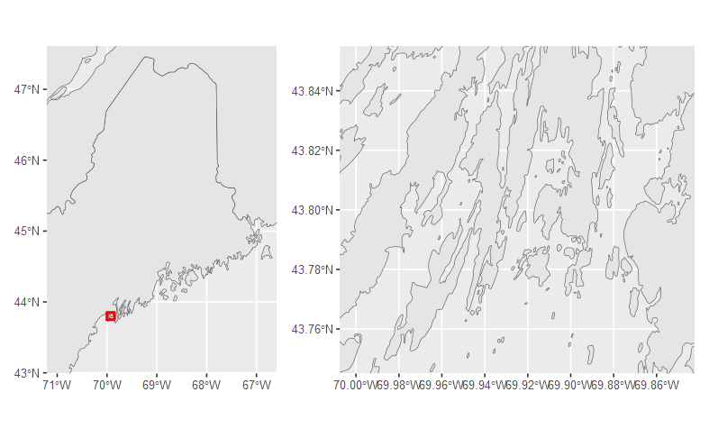

```r
# Show the combined map
combined_map
```

Cool. One more big task– let’s put some points on our map to show where the Dogs Head and Snow Island leases are.

```r
# Create dataframe of lease locations
# I just pulled these lat-lons off Google Maps satellite images
lease.locations <- data.frame(
  site_name = c('Snow Island', 'Dogs Head'),
  lat = c(43.816933, 43.795223),
  lon = c(-69.907845,  -69.953595)
)

# Convert dataframe to spatial object
lease.locations <- st_as_sf(lease.locations, coords=c('lon', 'lat'))

# Set CRS to be equal to our other shapefiles' CRS
st_crs(lease.locations) <- st_crs(qbc)

# Make and save map of Quahog Bay
qbc_map <- ggplot() +
  geom_sf(data=qbc) +
  geom_sf(data=lease.locations,
          aes(col=site_name)) +
  coord_sf(xlim=c(-70.00, -69.85),
           ylim=c(43.75, 43.85))

# Change legend title from site_name to Site Name
qbc_map <- qbc_map + guides(col=guide_legend(title="Site Name"))

# Combine
combined_map <- maine_map + qbc_map
```

|  | t | l | b | r |
| --- | --- | --- | --- | --- |
| 1: | 1 | 1 | 1 | 1 |
| 2: | 1 | 2 | 1 | 2 |

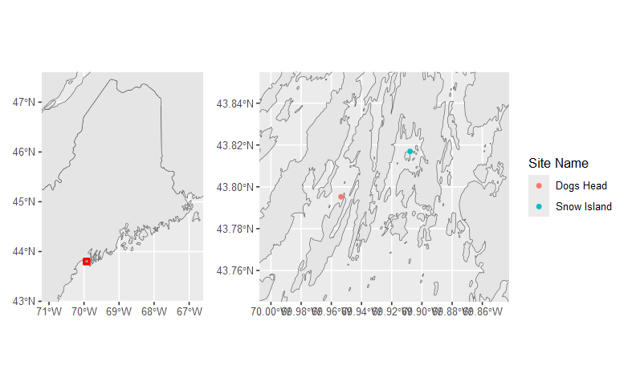

```r
# Show combined map
combined_map
```

We also want to make sure that our x-axis labels (longitude) are completely visible. They’re currently writing over each other. We can rotate these labels so that this doesn’t happen.

```r
# Set GGplot auto theme
theme_set(theme(panel.grid.major = element_line(color='lightgray'),
                panel.grid.minor = element_blank(),
                panel.background = element_blank(),
                panel.border = element_rect(color='black', linewidth=1, fill=NA)
                )
          )

# Make and save map of Quahog Bay with rotated x-axis labels
qbc_map <- ggplot() +
  geom_sf(data=qbc) +
  geom_sf(data=lease.locations,
          aes(col=site_name)) +
  coord_sf(xlim=c(-70.00, -69.85),
           ylim=c(43.75, 43.85)) +
  theme(axis.text.x = element_text(angle = 45)) +
  guides(col=guide_legend(title="Site Name"))

# Re-plot with new theme
combined_map <- maine_map + qbc_map
```

|  | t | l | b | r |
| --- | --- | --- | --- | --- |
| 1: | 1 | 1 | 1 | 1 |
| 2: | 1 | 2 | 1 | 2 |

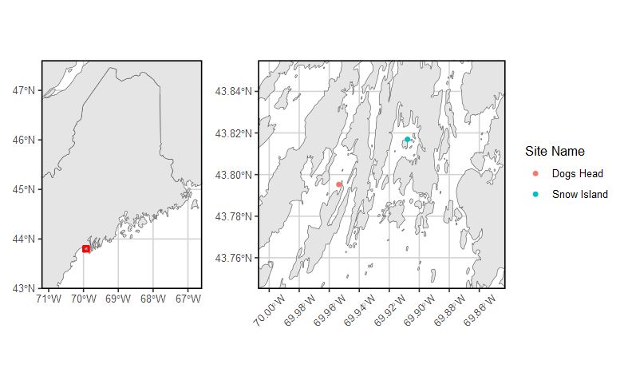

```r
# Show combined map
combined_map
```

This looks great! It should be our final map. Let’s save it as a .png (digital picture format) so that we can get a high picture quality for inclusion in your report.

```r
# Your filename needs to include the whole file path where you want this to save.
# If you don't like using the here package, write the entire file path.

# Save picture with the file name "oyster_lease_map"
ggsave(plot=combined_map,
       filename=here("oyster_lease_map.png"),
       device="png")
# Now you can go to this folder and find your new map picture there!
```